# Principal Component Analysis and Regression in R

Ann Stewart

June 20, 2016

Today we will take a look at failure data from a silver-zinc battery, that was collected to characterize the performace of the battery during its life cycle.

First we will take a look at the data.

```r
# Input the data into R
Battery <- read.table("BatteryFailureData.txt", header=TRUE)
# View the data
print(Battery)
```

```
##    ChargeRate DischargeRate DepthofDischarge Temperature EndofChargeVolt
## 1       0.375          3.13             60.0          40            2.00
## 2       1.000          3.13             76.8          30            1.99
## 3       1.000          3.13             60.0          20            2.00
## 4       1.000          3.13             60.0          20            1.98
## 5       1.625          3.13             43.2          10            2.01
## 6       1.625          3.13             60.0          20            2.00
## 7       1.625          3.13             60.0          20            2.02
## 8       0.375          5.00             76.8          10            2.01
## 9       1.000          5.00             43.2          10            1.99
## 10      1.000          5.00             43.2          30            2.01
## 11      1.000          5.00            100.0          20            2.00
## 12      1.625          5.00             76.8          10            1.99
## 13      0.375          1.25             76.8          10            2.01
## 14      1.000          1.25             43.2          10            1.99
```

[output cut: 27 more lines]

We will consider the first five variables as the independent ones, and Cycles to Failure as the dependent variable. Then we will regress the natural log of Cycles to Failure on the five independent variables.

```r
#Perform the regression
reg <- lm( log(CyclestoFailure) ~  ChargeRate + DischargeRate + DepthofDischarge + Temperature + EndofChargeVolt, data=Battery)
#View the summary
summary(reg)
```

```
##
## Call:
## lm(formula = log(CyclestoFailure) ~ ChargeRate + DischargeRate +
##     DepthofDischarge + Temperature + EndofChargeVolt, data = Battery)
##
## Residuals:
##     Min      1Q  Median      3Q     Max
## -2.0932 -0.6697  0.2702  0.7417  1.3986
##
## Coefficients:
##                   Estimate Std. Error t value Pr(>|t|)
## (Intercept)      -63.68324   51.17800  -1.244 0.233802
## ChargeRate        -0.45925    0.54926  -0.836 0.417124
## DischargeRate     -0.32668    0.17615  -1.855 0.084834 .
## DepthofDischarge  -0.01113    0.01699  -0.655 0.522932
## Temperature        0.11577    0.02499   4.633 0.000387 ***
## EndofChargeVolt   33.81176   25.58798   1.321 0.207560
## ---
## Signif. codes:  0 '***' 0.001 '**' 0.01 '*' 0.05 '.' 0.1 ' ' 1
##
## Residual standard error: 1.07 on 14 degrees of freedom
## Multiple R-squared:  0.6633, Adjusted R-squared:  0.543
## F-statistic: 5.515 on 5 and 14 DF,  p-value: 0.005184
```

There are several other useful functions for obtaining information about your regression.

```r
# Confidence intervals for the model parameters
confint(reg, level=0.95)
```

```
##                          2.5 %      97.5 %
## (Intercept)      -173.44913608 46.08264804
## ChargeRate         -1.63729059  0.71878868
## DischargeRate      -0.70447992  0.05111420
## DepthofDischarge   -0.04757348  0.02530783
## Temperature         0.06217718  0.16936112
## EndofChargeVolt   -21.06899801 88.69252597
```

```r
 # Predicted values for each observation
fitted(reg)
```

```
##        1        2        3        4        5        6        7        8
## 6.708344 4.738471 4.105929 3.429694 3.186355 3.818897 4.495132 2.775459
##        9       10       11       12       13       14       15       16
## 2.186254 5.177873 3.049719 1.525160 4.000519 3.411315 5.690753 2.404710
##       17       18       19       20
## 5.439666 4.433061 5.025503 4.392961
```

```r
# See the residuals for each observation
residuals(reg)
```

```
##           1           2           3           4           5           6
## -2.09322327  0.21028853  0.45841918  1.39862000  0.57484529 -1.04630845
##           7           8           9          10          11          12
##  0.74130951 -0.47287353 -1.08764216  0.77796472  0.75694346 -0.83201247
##          13          14          15          16          17          18
##  0.33021401  0.94539367 -0.61557896 -1.30609757 -0.06438783 -0.14260150
##          19          20
##  0.72388978  0.74283758
```

```r
# See the ANOVA table
anova(reg)
```

```
## Analysis of Variance Table
##
## Response: log(CyclestoFailure)
##                  Df  Sum Sq Mean Sq F value   Pr(>F)
## ChargeRate        1  1.4643  1.4643  1.2788 0.277132
## DischargeRate     1  4.5120  4.5120  3.9402 0.067097 .
## DepthofDischarge  1  0.2910  0.2910  0.2541 0.622051
## Temperature       1 23.3109 23.3109 20.3566 0.000488 ***
## EndofChargeVolt   1  1.9995  1.9995  1.7461 0.207560
## Residuals        14 16.0318  1.1451
## ---
## Signif. codes:  0 '***' 0.001 '**' 0.01 '*' 0.05 '.' 0.1 ' ' 1
```

```r
# covariance matrix for model parameters
vcov(reg)
```

```
##                    (Intercept)   ChargeRate DischargeRate DepthofDischarge
## (Intercept)       2.619188e+03 -0.470639345  4.781317e-01    -0.0055797366
## ChargeRate       -4.706393e-01  0.301683524  2.975900e-03     0.0027831717
## DischargeRate     4.781317e-01  0.002975900  3.102765e-02    -0.0005185778
## DepthofDischarge -5.579737e-03  0.002783172 -5.185778e-04     0.0002886716
## Temperature      -1.590972e-01  0.001649861  5.526368e-05    -0.0000129821
## EndofChargeVolt  -1.308976e+03 -0.028297143 -2.720426e-01    -0.0068055413
##                    Temperature EndofChargeVolt
## (Intercept)      -1.590972e-01   -1.308976e+03
## ChargeRate        1.649861e-03   -2.829714e-02
## DischargeRate     5.526368e-05   -2.720426e-01
## DepthofDischarge -1.298210e-05   -6.805541e-03
## Temperature       6.243545e-04    7.297099e-02
## EndofChargeVolt   7.297099e-02    6.547448e+02
```

As you can see, this model for regression does not fit the data very well. To remedy the situation, we consider Principal Component Analysis.

Principal Component Analysis, or PCA, is a multivariate statistical technique that converts a set of correlated variables into a set of orthogonal, uncorrelated axes called principal components. PCA models the variation in the set of original variables in terms of a smaller number of independent linear combinations of those original variables. The goal is to extract as much information as possible about the variance-covariance structure of the variables using only a few principal components.

Here we take a look at it with our battery data.

```r
#Find the Principal Components of the independent variables

# Create a data frame with only the five independent variables
Independent <- data.frame(Battery[1:5])

# Perform the Principal Component Analysis
PCAbatteries <- princomp(Independent)

# View the summary
summary(PCAbatteries)
```

```
## Importance of components:
##                            Comp.1    Comp.2      Comp.3       Comp.4
## Standard deviation     15.0991154 9.6968574 1.361404508 0.4356009798
## Proportion of Variance  0.7035314 0.2901633 0.005719458 0.0005855422
## Cumulative Proportion   0.7035314 0.9936947 0.999414188 0.9999997301
##                              Comp.5
## Standard deviation     9.351386e-03
## Proportion of Variance 2.698562e-07
## Cumulative Proportion  1.000000e+00
```

Next it will be helpful to see a Scree Plot of the principal components. A scree plot displays the eigenvalues associated with each component in descending order versus the number of the component. You can use scree plots in principal components analysis to visually assess which components or factors explain most of the variability in the data.

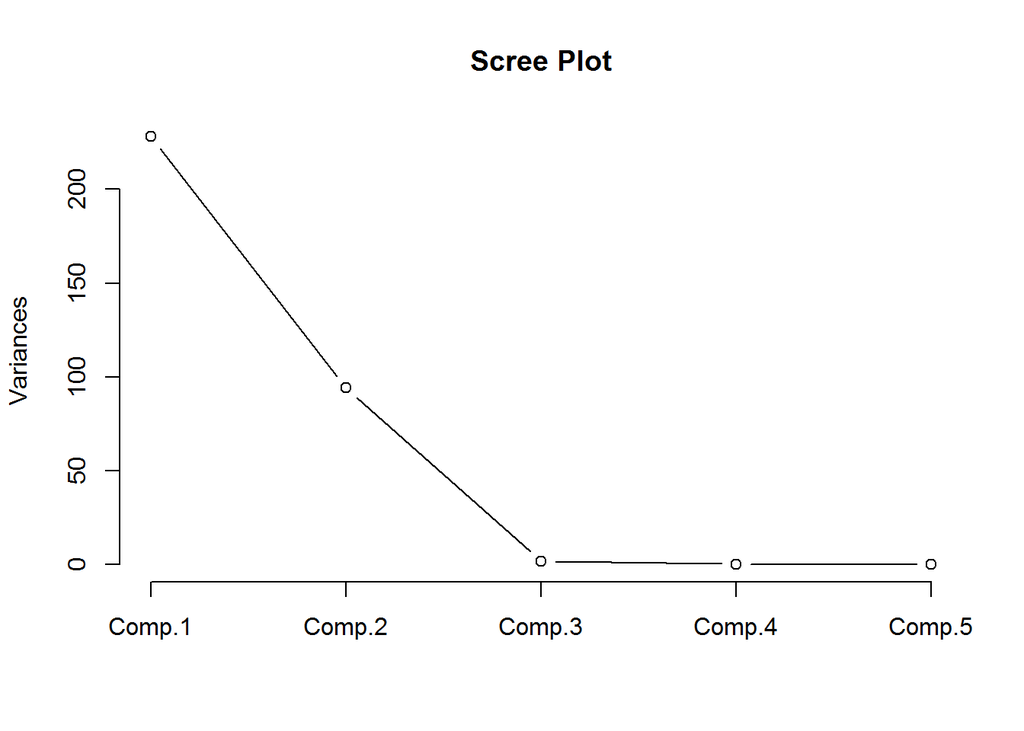

```r
#  See the Scree Plot

plot(PCAbatteries,type="lines", main="Scree Plot")
```

It is clear from the Scree Plot and from the proportion of variance that the first two principal components are the essential ones. Those will be the ones regressed upon the dependent variable, Cycles to Failure.

The following functions will give you the evaluated principal components as well as the specific loadings.

```r
# View the evaluated principal components for each observation
PCAbatteries$scores
```

```
##           Comp.1      Comp.2     Comp.3      Comp.4       Comp.5
##  [1,]   1.316231  20.6557349  0.2007364 -0.56870421  0.003302512
##  [2,] -14.693430   9.4447593 -0.1310889  0.15605450 -0.008013627
##  [3,]   2.792951   0.7072532  0.1490980 -0.05360565  0.001046498
##  [4,]   2.792952   0.7072555  0.1490897 -0.05360659 -0.018953500
##  [5,]  20.285447  -8.0332280  0.4225522  0.36166095  0.010079597
##  [6,]   2.799066   0.7042780  0.1423653  0.57132110  0.001019473
##  [7,]   2.799065   0.7042758  0.1423735  0.57132204  0.021019471
##  [8,] -13.262027 -10.5045358  1.7003297 -0.55826567  0.009007397
##  [9,]  20.246244  -8.0370120  2.2988598 -0.24283294 -0.010670387
## [10,]  18.775637  11.9084923  2.3437737 -0.13300382  0.011558600
## [11,] -37.123658  -2.2405757  1.2981202  0.33527229 -0.000146275
## [12,] -13.249799 -10.5104838  1.6868559  0.69158687 -0.011046652
## [13,] -13.195671 -10.4909769 -2.0488344 -0.59924254  0.010565574
## [14,]  20.312600  -8.0234531 -1.4503043 -0.28380982 -0.009112210
## [15,] -14.660164   9.4515557 -2.0106657  0.13551190  0.002767539
## [16,]   4.296825 -19.2314558 -1.7753886 -0.18397690 -0.000401325
## [17,]  18.848107  11.9190783 -1.4121314  0.45094510 -0.006910246
## [18,]   2.832332   0.7110756 -1.7372157  0.55077802  0.001800639
## [19,] -14.699544   9.4477344 -0.1243561 -0.46887224 -0.007986602
## [20,]   2.786837   0.7102283  0.1558308 -0.67853239  0.001073523
```

```r
# View the specific loadings for each observation
loadings(PCAbatteries)
```

```
##
## Loadings:
##                  Comp.1 Comp.2 Comp.3 Comp.4 Comp.5
## ChargeRate                             1.000
## DischargeRate                   1.000
## DepthofDischarge -0.997
## Temperature              0.997
## EndofChargeVolt                               1.000
##
##                Comp.1 Comp.2 Comp.3 Comp.4 Comp.5
## SS loadings       1.0    1.0    1.0    1.0    1.0
## Proportion Var    0.2    0.2    0.2    0.2    0.2
## Cumulative Var    0.2    0.4    0.6    0.8    1.0
```

In order to regress the principal components on the dependent variable, we need to create a new dataset of the principal components evaluated at each observation.

```r
# Create the new dataset of the principal components evaluated at each observation.
PrincipalComponents <- data.frame(PCAbatteries$scores)
New <- data.frame(PrincipalComponents[1:2],Battery[6])

# View the new dataset to make sure it was created in the way we intended
print(New)
```

```
##        Comp.1      Comp.2 CyclestoFailure
## 1    1.316231  20.6557349             101
## 2  -14.693430   9.4447593             141
## 3    2.792951   0.7072532              96
## 4    2.792952   0.7072555             125
## 5   20.285447  -8.0332280              43
## 6    2.799066   0.7042780              16
## 7    2.799065   0.7042758             188
## 8  -13.262027 -10.5045358              10
## 9   20.246244  -8.0370120               3
## 10  18.775637  11.9084923             386
## 11 -37.123658  -2.2405757              45
## 12 -13.249799 -10.5104838               2
## 13 -13.195671 -10.4909769              76
## 14  20.312600  -8.0234531              78
## 15 -14.660164   9.4515557             160
## 16   4.296825 -19.2314558               3
## 17  18.848107  11.9190783             216
## 18   2.832332   0.7110756              73
## 19 -14.699544   9.4477344             314
## 20   2.786837   0.7102283             170
```

Now that we see the dataset is correct, we can perform the regression of the first two principal components on the natural log of the dependent variable, Cycles to Failure.

```r
# Perform the regression
reg2 <- lm( log(CyclestoFailure) ~  Comp.1 + Comp.2, data=New)

# View the summary of the regression
summary(reg2)
```

```
##
## Call:
## lm(formula = log(CyclestoFailure) ~ Comp.1 + Comp.2, data = New)
##
## Residuals:
##     Min      1Q  Median      3Q     Max
## -2.0427 -0.4975  0.1985  0.7152  1.5929
##
## Coefficients:
##             Estimate Std. Error t value Pr(>|t|)
## (Intercept) 3.999789   0.256300  15.606 1.65e-11 ***
## Comp.1      0.003568   0.016974   0.210 0.836001
## Comp.2      0.115798   0.026431   4.381 0.000407 ***
## ---
## Signif. codes:  0 '***' 0.001 '**' 0.01 '*' 0.05 '.' 0.1 ' ' 1
##
## Residual standard error: 1.146 on 17 degrees of freedom
## Multiple R-squared:  0.5309, Adjusted R-squared:  0.4757
## F-statistic: 9.619 on 2 and 17 DF,  p-value: 0.001607
```

It does not appear that this model is much better. Let us try the regression with only the first principal component.

```r
# Perform the regression
reg3 <- lm(log(CyclestoFailure) ~ Comp.1, data=New)
#  View the summary
summary(reg3)
```

```
##
## Call:
## lm(formula = log(CyclestoFailure) ~ Comp.1, data = New)
##
## Residuals:
##     Min      1Q  Median      3Q     Max
## -3.2594 -0.5425  0.4663  1.1265  1.8891
##
## Coefficients:
##             Estimate Std. Error t value Pr(>|t|)
## (Intercept) 3.999789   0.363438  11.005 2.01e-09 ***
## Comp.1      0.003568   0.024070   0.148    0.884
## ---
## Signif. codes:  0 '***' 0.001 '**' 0.01 '*' 0.05 '.' 0.1 ' ' 1
##
## Residual standard error: 1.625 on 18 degrees of freedom
## Multiple R-squared:  0.001219,   Adjusted R-squared:  -0.05427
## F-statistic: 0.02198 on 1 and 18 DF,  p-value: 0.8838
```

Now we can use an ANOVA test to compare the previous two models. The following code provides a simultaneous test that Comp.2 adds to linear prediction above and beyond Comp.1.

```r
anova(reg2, reg3)
```

```
## Analysis of Variance Table
##
## Model 1: log(CyclestoFailure) ~ Comp.1 + Comp.2
## Model 2: log(CyclestoFailure) ~ Comp.1
##   Res.Df    RSS Df Sum of Sq      F    Pr(>F)
## 1     17 22.334
## 2     18 47.551 -1   -25.217 19.194 0.0004074 ***
## ---
## Signif. codes:  0 '***' 0.001 '**' 0.01 '*' 0.05 '.' 0.1 ' ' 1
```

The significance of this test means that the two models are indeed different. However, neither of them looks to be a good model.